# Google Data Analytics Capstone: Cyclistic

Pat Tarantino

2023-01-19

## **1. Introduction**

#### The following markdown file documents all steps, code, and tools used to perform my analysis of the Cyclistic ride share system.

#### This project was presented as an optional capstone project for the Google Grow Data Analytics Certification program.

## **Scenario**

#### In this assignment, I was asked to fill the role of a junior data analyst working for the Cyclistic bike share program.

#### Since it’s inception in 2016, Cyclistic grown to a fleet of 5,824 geotracked bikes that can be rented and returned through a network of 692 stations across Chicago, IL.

#### Cyclistic users can choose from three pricing plans: single-ride passes, full-day passes, and an annual membership. Single-ride and full-day pass users are internally referred to as “casual riders,” while annual membership holders are called “members.”

## **Business Objective**

#### Cyclistic leadership plans to increase revenue by developing a digital marketing campaign to convert casual customers into annual subscribers. A successful, data-driven marketing campaign depends on a clear understanding of current casual/member behavior.

## **Key Stakeholders**

#### **Lily Moreno, Cyclistic director of marketing:** My direct report on this assignment and my line of communication to Cyclistic’s digital marketing team, who will create a campaign based on my analysis.

#### **Cyclistic Executive Team:** The executive team will have final approval for the digital marketing campaign presented by Lily Moreno and her team.

## **Business Task**

#### My business task is to clean, prepare, and analyze the last year of Cyclistic ride data. These findings will then be vizualized and presented with recommendations for an effective digital marketing strategy that will convince casual customers to purchase an annual Cyclistic membership.

#### To complete my objective, I will need to answer the following questions:

#### **1. How do annual members and casual riders use Cyclistic bikes differently?**

#### **2. Why would casual riders buy Cyclistic annual memberships?**

#### **3. How can Cyclistic use digital media to convince casual riders to become members?**

## **2. Datasets Used in Analysis and Tool Selection**

## **Overview**

#### My primary source of data for this project are monthly ride reports maintained internally by Cyclistic, which document all customer activity within the system.

#### Cyclsitic monthly ride reports can be found [here](https://divvy-tripdata.s3.amazonaws.com/index.html)

#### I also chose to incorporate a secondary source of data in my analysis: a daily weather report for the Chicago area covering my period of study.

#### Chicago daily weather reports were acquired via [Visual Crossing Weather API Service.](https://www.visualcrossing.com/weather/weather-data-services#)

## **Data Organization**

#### Cyclistic monthly ride reports are stored in .csv files that are uploaded on a monthly basis. The 12 most recent monthly reports were used for this report (September 2021 - August 2022.)

#### These reports include data like the **type of bike** used, **customer type**, **start and end station names**, **start and end station GPS coordinates**, and **date/timestamps** logged at the beginning and conclusion of each ride.

#### Chicago daily weather reports were stored in a single .csv file and include average daily temperature, total rainfall, humidity, and other environmental factors during the same period of study (September 2021 - August 2022.)

## **Data Credibility**

#### Ride data is *original* and collected *directly* by Motivate, inc., the company that manages Chicago’s Cyclistic system. This data is *comprehensive* as it includes all rides taken during the period of study, *current* because it includes the latest ride data available at time of study, and clearly *cited*.

#### Weather data was orginally collected directly by the US National Weather Service API and is considered open data to the public. Visualcrossing.com was used as the source for this data because it compiles multiple NWS API reports into a single document for ease of use and is clearly cited. A review of Visual Crossing and NWS API reports shows they offer identical data for the period of study.

## **Data Licensing, Security, Privacy, and Accessibility**

#### Cyclistic ride data is made available under the following [license](https://ride.divvybikes.com/data-license-agreement), while NWS API data is made available as [open data](https://www.weather.gov/documentation/services-web-api) by the US government.

#### Cyclistic data is anonymized to protect user privacy with no identifying demographic attributes provided beyond Cyclistic membership status. This data anonymization will close some avenues of customer-pattern analysis, but still provides sufficient information for our level of analysis.

## **Tool Selection**

#### Due to the size of this dataset (5,883,043 documented rides,) spreadsheets lack the processing power to perform practical analysis. An SQL tool like BigQuery can handle a dataset of this size, however the lack of in-program visualization tools will limit our ability to identify trends worth further investigation as our analysis proceeds.

#### As a result, I chose to use R Studio for this project, as it has the power to maniuplate such a large data set, readily-available packages to complete complex tasks, and allows me to visualize findings as I proceed.

#### In addition to R, I also periodically used a Google Sheet for basic calculations and to quickly highlight interesting data points with conditional formatting. Relevant pages are linked throuhgout the report when used.

## **3. Workspace Preparation**

#### To complete this assignment, I need to review, clean, analyze, and visualize rider data. I chose the following packages to complete these tasks.

```r
library(tidyverse) ## Basic data manipulation
library(lubridate) ## Transforms dates and time stamps
library(ggplot2) ## Visualization tool
library(readxl) ## Data read-in utility
library(skimr) ## High-level data review
library(janitor) ## General-purpose data cleaning utility
library(mapview) ## Geographic visualization in R
library(RColorBrewer) ## Wider palette range for visualizations
library(geosphere) ## Calculates distances between GPS coordinates
library(ggpubr) ## Improved visualization display for side-by-side comparison
```

```r
mapviewOptions(fgb = FALSE, georaster = FALSE)
```

## **4. Data Import**

#### User data is stored in 12 csv files. Each file was found to have identical schema, so there is no need to modify these files prior to being bound into a single dataframe. The Chicago Weather file will be left unbound, as all annual data is already compiled into a single file.

```r
getwd() ## Determine current directory
```

```
## [1] "A:/Cyclistic Final"
```

```r
## Initial data import
rides_2109 <- read.csv('202109_raw_data.csv')
rides_2110 <- read.csv('202110_raw_data.csv')
rides_2111 <- read.csv('202111_raw_data.csv')
rides_2112 <- read.csv('202112_raw_data.csv')
rides_2201 <- read.csv('202201_raw_data.csv')
rides_2202 <- read.csv('202202_raw_data.csv')
rides_2203 <- read.csv('202203_raw_data.csv')
rides_2204 <- read.csv('202204_raw_data.csv')
rides_2205 <- read.csv('202205_raw_data.csv')
rides_2206 <- read.csv('202206_raw_data.csv')
rides_2207 <- read.csv('202207_raw_data.csv')
rides_2208 <- read.csv('202208_raw_data.csv')
chicago_weather <- read.csv('chicago weather.csv')
```

#### Binding Monthly Reports

```r
annual_trips <- rbind(rides_2109,
                      rides_2110,
                      rides_2111,
                      rides_2112,
                      rides_2201,
                      rides_2202,
                      rides_2203,
                      rides_2204,
                      rides_2205,
                      rides_2206,
                      rides_2207,
                      rides_2208)
```

#### Removing source files to keep a tidy workspace

```r
rm(rides_2109,
   rides_2110,
   rides_2111,
   rides_2112,
   rides_2201,
   rides_2202,
   rides_2203,
   rides_2204,
   rides_2205,
   rides_2206,
   rides_2207,
   rides_2208)
```

## **5. Data Inspection and Cleaning (annual_trips)**

```r
glimpse(annual_trips)
```

```
## Rows: 5,883,043
## Columns: 13
## $ ride_id            <chr> "9DC7B962304CBFD8", "F930E2C6872D6B32", "6EF7213790…
## $ rideable_type      <chr> "electric_bike", "electric_bike", "electric_bike", …
## $ started_at         <chr> "2021-09-28 16:07:10", "2021-09-28 14:24:51", "2021…
## $ ended_at           <chr> "2021-09-28 16:09:54", "2021-09-28 14:40:05", "2021…
## $ start_station_name <chr> "", "", "", "", "", "", "", "", "", "", "Clark St &…
## $ start_station_id   <chr> "", "", "", "", "", "", "", "", "", "", "TA13070001…
## $ end_station_name   <chr> "", "", "", "", "", "", "", "", "", "", "", "", "",…
## $ end_station_id     <chr> "", "", "", "", "", "", "", "", "", "", "", "", "",…
## $ start_lat          <dbl> 41.89000, 41.94000, 41.81000, 41.80000, 41.88000, 4…
## $ start_lng          <dbl> -87.68000, -87.64000, -87.72000, -87.72000, -87.740…
## $ end_lat            <dbl> 41.89, 41.98, 41.80, 41.81, 41.88, 41.88, 41.74, 41…
## $ end_lng            <dbl> -87.67, -87.67, -87.72, -87.72, -87.71, -87.74, -87…
## $ member_casual      <chr> "casual", "casual", "casual", "casual", "casual", "…
```

#### Glimpse reveals several issues with our annual_trips dataset we will need to address through cleaning:

#### 1. Timestamps for started_at and ended_at are stored as strings. We will cast these as numeric and use lubridate to break out month, week, day, and hour for more granular analysis.

#### 2. Station gps data is also recorded as doubles. I will change these to numeric values to avoid possible rounding issues later.

#### 3. Glimpse also presents us with a significant issue regarding location data: many station names are missing, possibly due to truncated gps coordinates.

```r
skim(annual_trips)
```

Data summary

| Name | annual_trips |
| --- | --- |
| Number of rows | 5883043 |
| Number of columns | 13 |
| _______________________ |  |
| Column type frequency: |  |
| character | 9 |
| numeric | 4 |
| ________________________ |  |
| Group variables | None |

**Variable type: character**

| skim_variable | n_missing | complete_rate | min | max | empty | n_unique | whitespace |
| --- | --- | --- | --- | --- | --- | --- | --- |
| ride_id | 0 | 1 | 16 | 16 | 0 | 5883043 | 0 |
| rideable_type | 0 | 1 | 11 | 13 | 0 | 3 | 0 |
| started_at | 0 | 1 | 19 | 19 | 0 | 4912339 | 0 |
| ended_at | 0 | 1 | 19 | 19 | 0 | 4919944 | 0 |
| start_station_name | 0 | 1 | 0 | 64 | 884365 | 1439 | 0 |
| start_station_id | 0 | 1 | 0 | 44 | 884363 | 1273 | 0 |
| end_station_name | 0 | 1 | 0 | 64 | 946303 | 1453 | 0 |
| end_station_id | 0 | 1 | 0 | 44 | 946303 | 1282 | 0 |
| member_casual | 0 | 1 | 6 | 6 | 0 | 2 | 0 |

**Variable type: numeric**

| skim_variable | n_missing | complete_rate | mean | sd | p0 | p25 | p50 | p75 | p100 | hist |
| --- | --- | --- | --- | --- | --- | --- | --- | --- | --- | --- |
| start_lat | 0 | 1 | 41.90 | 0.05 | 41.64 | 41.88 | 41.90 | 41.93 | 45.64 | ▇▁▁▁▁ |
| start_lng | 0 | 1 | -87.65 | 0.03 | -87.84 | -87.66 | -87.64 | -87.63 | -73.80 | ▇▁▁▁▁ |
| end_lat | 5727 | 1 | 41.90 | 0.05 | 41.39 | 41.88 | 41.90 | 41.93 | 42.37 | ▁▁▇▁▁ |
| end_lng | 5727 | 1 | -87.65 | 0.03 | -88.97 | -87.66 | -87.64 | -87.63 | -87.50 | ▁▁▁▁▇ |

#### 2. “ride_id” is our primary key in this data frame, and we have 5,883,043 unique records, meaning that there are no duplicate entries to clean.

#### 3. While the Cyclistic system has two bike types, electric and classic, there is a third category, “docked”, that will require additional research. It is possible these are the adaptive bikes mentioned in the assignment brief, but this will require investigation due to a lack of real-world subject matter experts to consult.

## **Investigating Missing Start/End Station Data**

#### I will first create a dataset that includes all rides with empty start/end station fields and then use the count command to see if there are any commonalities between these records.

```r
missing_station_data <- annual_trips %>%
  filter(start_station_id == ""|
           end_station_id == ""|
           start_station_name == "" |
           end_station_name == ""
         )
```

#### Identifying common trends in missing data.

```r
count(missing_station_data, rideable_type)
```

```
##   rideable_type       n
## 1  classic_bike    5843
## 2   docked_bike    2209
## 3 electric_bike 1314845
```

```r
count(missing_station_data, member_casual)
```

```
##   member_casual      n
## 1        casual 590488
## 2        member 732409
```

#### The above count commands show that missing station data occurs across all bike types and customer types.

#### Next I will create four datasets using the filter command to locate any start/end station records that can be repaired, rather than removed.

```r
partial_data <- missing_station_data %>%
  filter(start_station_id == ""&
           start_station_name != ""
         )
partial_data_2 <- missing_station_data %>%
  filter(start_station_name == ""&
           start_station_id != ""
         )

partial_data_3 <- missing_station_data %>%
  filter(end_station_id == ""&
           end_station_name != ""
         )

partial_data_4 <- missing_station_data %>%
  filter(end_station_name == ""&
           end_station_id != ""
         )
```

#### These filters reveal only two partial records where start station name is not present, but there is a start station id (20215 and WL-008.) I will now attempt to repair those records by first identifying the station names we need to add to these records.

```r
partial_station_1 <- annual_trips %>%
  filter(end_station_id == "WL-008")

partial_station_2 <- annual_trips %>%
  filter(end_station_id == "20215")
```

#### I will now “repair” those records using the station names I recovered:

```r
annual_trips$start_station_name[
  annual_trips$start_station_id == "WL-008"] <- "Clinton St & Roosevelt Rd" ## modifying record

annual_trips_check_1 <- annual_trips %>%
filter(ride_id == "EE197EDA4CF8CFE5") ## Confirming modification

rm(annual_trips_check_1,
   partial_station_1)

annual_trips$start_station_name[
annual_trips$start_station_id == "20215"] <- "Hegewisch Metra Station" ## modifying record

annual_trips_check_2 <- annual_trips %>%
filter(ride_id == "DE82A15026BA3056") ## Confirming modification

rm(annual_trips_check_2,
   partial_station_2)

rm(partial_data,
   partial_data_2,
   partial_data_3,
   partial_data_4) ## Cleaning workspace
```

#### After salvaging the records I could, I will now need to address NA entries in station data.

```r
colSums(is.na(missing_station_data))
```

```
##            ride_id      rideable_type         started_at           ended_at
##                  0                  0                  0                  0
## start_station_name   start_station_id   end_station_name     end_station_id
##                  0                  0                  0                  0
##          start_lat          start_lng            end_lat            end_lng
##                  0                  0               5727               5727
##      member_casual
##                  0
```

#### This quick check of NA values found 5727 records(0.097% of all records) lack any ending gps data. I will first create a dataframe highlighting these records.

```r
missing_gps_data <- missing_station_data %>%
  filter(
    is.na(
    end_lat|
      end_lng
      )
    )
```

#### With these rides isolated, I will now use group and count functions to try and identify any commonalities in these records.

```r
missing_gps_data_2 <- missing_gps_data %>%
  group_by(member_casual) %>%
  count(rideable_type,
        name = "ride_count")
```

#### This reveals a trend: Only “docked” and “classic” bike types have null gps data. Since many rideshare systems start with pedal-powered bikes only, this could mean these bikes are some of the oldest in the fleet and may be experiencing some type of hardware failure, or were never docked and are potentially stolen. These trips will be removed from our study due to their ambiguity.

#### In a real-world scenario, I would speak with a subject matter expert from Cyclistic’s operations team to better understand the implications of these missing records before removing them from my study.

```r
## Clearing old datasets
rm(missing_gps_data,
  missing_gps_data_2)
```

```r
annual_trips_1 <- annual_trips %>% ## Filtering NA gps data
  filter(!is.na(end_lat),
         !is.na(end_lng)
         )
colSums(is.na(annual_trips_1)) ## Verifying removal
```

```
##            ride_id      rideable_type         started_at           ended_at
##                  0                  0                  0                  0
## start_station_name   start_station_id   end_station_name     end_station_id
##                  0                  0                  0                  0
##          start_lat          start_lng            end_lat            end_lng
##                  0                  0                  0                  0
##      member_casual
##                  0
```

#### Removing NA values helps ensure the accuracy of our study, however we need a better understanding of why so many records are missing station-to-station data. The command below will group records by start/end lat/lng so that we can find common causes.

```r
missing_start_lat <- missing_station_data %>% ## Filtering and grouping by start_lat to find common causes
  filter(start_station_name == "") %>%
  count(start_lat,
        wt = NULL,
        sort = TRUE,
        name = "instances"
        )

missing_start_lng <- missing_station_data %>%
  filter(start_station_name == "") %>%
  count(start_lng,
        wt = NULL,
        sort = TRUE,
        name = "instances"
  )
```

#### This reveals the cause for missing station data: gps coordinates are typically 7 digits long, and these entries lack anywhere from 1 to 5 digits, making them too innacurate to be mapped to stations. We will now perform the same test on end stations to ensure this is a consistent issue.

```r
missing_end_lat <- missing_station_data %>%
  filter(end_station_name == "") %>%
  count(end_lat,
        wt = NULL,
        sort = TRUE,
        name = "instances"
  )

missing_end_lng <- missing_station_data %>%
  filter(end_station_name == "") %>%
  count(end_lng,
        wt = NULL,
        sort = TRUE,
        name = "instances"
  )
```

#### Once again, we see truncated gps coordinates are the cause for this missing station data.

```r
## clearing old datasets
rm(missing_start_lat,
  missing_start_lng,
  missing_end_lat,
  missing_end_lng)
```

#### Now that we know the cause for this incomplete data, we need to decide whether or not to include it in our analysis.

#### I came to the following decision: There are 1,322,897, or 22.51% of our total records missing station data. Ignoring this many records completely may skew our analysis. Instead, I will continue to use these records for our behavioral analysis of customers, however they will be excluded from station-to-station analysis later in the study.

#### The missing_gps_data_2 data set raises questions about “docked bikes” that I need to understand before analysis. It appears that only casual customers used docked bikes in missing_gps_data_2. I want to look at the entire data set and see if that is true for the entire period of study.

```r
bike_type <- annual_trips_1 %>%
  group_by(member_casual, rideable_type) %>%
  summarize(ride_count = n_distinct(ride_id)
            )
bike_type_2 <- bike_type %>%
mutate(pct_ride_count = ((ride_count/sum(ride_count))*100))
```

```r
## Clearing old datasets
rm(bike_type,
  bike_type_2,
  missing_station_data)
```

#### It appears that this trend is consistent across our entire period of study: docked bikes appear to only be used by casual customers. Docked bikes make up 3.5% of all rides and 8.35% of all casual rides in our period of study. This will require further study and a decision later on whether or not to include these records in our analysis.

## **6. Subject Matter Expert Consultation**

#### The data inspection and cleaning process is not complete, but our process has already generated several questions that will dictate how we proceed with the rest of our data cleaning.

#### In a real-world scenario, I would stop at this point and consult with a subject matter expert from Cyclistic’s operations team and ask the following:

#### 1: **Does incomplete gps data indicate a mechanical or software fault, or possible theft/improper return of a bike?** If so, these rides may skew results and need to be removed from our analysis.

#### 2: **What does the “docked bike” designation actually mean?** Since it is only used by casual customers, I believe it may indicate a promotional ride offered through a marketing initiative, or it could indicate a bike removed from a dock for maintenance.

#### 3: Most bicycle share systems have limitations on how long a rider can use a bike before incurring financial penalties. I would need to speak with someone in the operations team to understand:

#### **A) What are the time limits for casual/member riders?**

#### **B) Is exceeding these time limits Considered a negative outcome for the system by lowering the number of available bikes, or a positive outcome, as longer rides increase revenue?**

#### Understanding these elements of the system and its goals would make it easier for me to identify optimal bike usage patterns.

## **7. Assumptions**

#### Because I do not have access to a subject matter expert, I made the following assumptions to guide the remainder of my cleaning and analysis:

#### 1. Rides with incomplete station data make up nearly 23% of all rides on the system, and thus their complete removal can have a major impact on our findings. As a result, I will keep these rides for my trip length and bike type analyses, however I will remove them from any analysis of geographic, station-to-station behavior.

#### 2. Rides with null end-station data might indicate theft of a bike or the bike’s removal from circulation for maintenance. As a result, these rides will be removed from all analysis.

#### 3. Docked bikes make up a small (3.53%) percent of overall rides and are only used by “casual” customers. When my data is cleaned, I will look at how these rides differ in duration compared to non-docked casual rides and make a decision on whether or not to remove these trips from my casual/member comparison.

#### 4. I do not have parameters for Cyclistic’s rental duration. As a result, I will use the following conditions when choosing to include or remove a given trip:

#### 4a. Rides under one minute may indicate the rental of a bike that had mechanical issues like a flat tire, or a customer simply “testing” a dock. Since sub-1-minute rides are unlikely to be actual station-to-station rides, these will be removed from all analysis.

#### 4b. Because I do not have information about rental durations, I will make the assumption that any rides with a duration of 8 hours or less are acceptable to the Cyclistic systems terms of service. However, I will remove any rides that last for more than 8 hours from my analyis, as these might indicate a lost/stolen bike, or a failure to properly dock, leading to others using the bike without the original user’s permission and skewing data.

## **8. Resuming Data Cleaning With New Assumptions**

## **Renaming and Checking Columns**

#### I will be spending a long time with this data, so I will simplify the dataframe name, bike_type and member_casual columns for easier use during analysis and visualization.

```r
trips_1 <- annual_trips_1 %>%
  rename('bike_type' = rideable_type,
         'customer_type' = member_casual
  ) %>%
  clean_names()
```

```r
rm(annual_trips,
   annual_trips_1)
```

## **Adapting Timestamps**

#### Some of the most valuable data we can harvest lives inside of “started_at” and “ended_at” fields, however it needs to be broken out to be properly studied.

#### The following code will use mutate to create a calendar day, week, month, weekday, and starting hour. We will also use difftime to determine the length of time a bike is in use. *Note* in order to avoid potential rounding errors in the future, I will measure all rides in seconds unless otherwise stated.

```r
trips_2 <- trips_1 %>%
  mutate(
    weekday = wday(started_at, label = T, abbr = F),
    month = month(started_at, label = T, abbr =F),
    week = strftime(started_at, format = "%V"),
    day = day(started_at),
    start_hour = hour(started_at),
    trip_length = as.numeric(difftime(ended_at, started_at,units = "secs"))
  )
```

```r
rm(trips_1)
```

## **Testing Trip Length**

#### Trip length will be a critical element of our study, so I will run some quick tests to identify any potential issues with this new field.

```r
max(trips_2$trip_length)
```

```
## [1] 2442301
```

```r
min(trips_2$trip_length)
```

```
## [1] -8245
```

#### Max trip length appears to be 28.27 days. This should not be an issue since we plan to filter 8+-hour rides, however our minimum value is a negative value of -8245. This indicates a possible error in the code, so I will now filter those negative values for study.

```r
time_check <- trips_2 %>%
filter(trip_length < 0)
```

#### time_check shows us 135 records with negative time values. Reviewing the first lines of time_check reveal that start times are occuring AFTER end times, suggesting some error in data collection.

#### I will now verify that is the case for all 135 records using case_when.

```r
time_check_2 <- time_check %>%
  mutate(calc_check =
    case_when(started_at > ended_at ~ 'no calc error',
              TRUE ~ 'calc error')
        )
time_check_3 <- time_check_2 %>%
  group_by(calc_check) %>%
  count(calc_check,
        name = "count")
```

```r
rm(time_check, time_check_2, time_check_3)
```

#### time_check_3 verifies that the negative time values are a result of faulty data collection.

#### Rather than multiplying each negative value by -1 and re-adding to our dataset, I will remove these rides because I cannot confirm their veracity.

#### Per the assumptions above and the results of our time check, I will now remove all rides shorter than a minute and longer than 8 hours (28,800 seconds.)

```r
trips_3 <- trips_2 %>%
  filter(trip_length >= 60,
         trip_length <= 28800)
```

#### This filter removed a total of 114,714 records from our dataset.

## **Recasting GPS Coordinates**

#### In my experience, some commands and packages in R can round unpredictably when working with doubles, so I will now recast gps coordinates as numeric data to avoid potential issues.

```r
trips_4 <- trips_3 %>%
  transform(start_lat = as.numeric(start_lat),
            start_lng = as.numeric(start_lng),
            end_lat = as.numeric(end_lat),
            end_lng = as.numeric(end_lng),
            trip_length = as.numeric(trip_length)
  )
```

```r
rm(trips_2,
   trips_3)
```

## **Checking Our Work**

#### I will now use skim_without_charts to test trips_4 for any further missing records before proceeding.

```r
skim_without_charts(trips_4)
```

Data summary

| Name | trips_4 |
| --- | --- |
| Number of rows | 5762602 |
| Number of columns | 19 |
| _______________________ |  |
| Column type frequency: |  |
| character | 10 |
| factor | 2 |
| numeric | 7 |
| ________________________ |  |
| Group variables | None |

**Variable type: character**

| skim_variable | n_missing | complete_rate | min | max | empty | n_unique | whitespace |
| --- | --- | --- | --- | --- | --- | --- | --- |
| ride_id | 0 | 1 | 16 | 16 | 0 | 5762602 | 0 |
| bike_type | 0 | 1 | 11 | 13 | 0 | 3 | 0 |
| started_at | 0 | 1 | 19 | 19 | 0 | 4828104 | 0 |
| ended_at | 0 | 1 | 19 | 19 | 0 | 4835266 | 0 |
| start_station_name | 0 | 1 | 0 | 64 | 856399 | 1437 | 0 |
| start_station_id | 0 | 1 | 0 | 44 | 856399 | 1271 | 0 |
| end_station_name | 0 | 1 | 0 | 64 | 903201 | 1450 | 0 |
| end_station_id | 0 | 1 | 0 | 44 | 903201 | 1280 | 0 |
| customer_type | 0 | 1 | 6 | 6 | 0 | 2 | 0 |
| week | 0 | 1 | 2 | 2 | 0 | 52 | 0 |

**Variable type: factor**

| skim_variable | n_missing | complete_rate | ordered | n_unique | top_counts |
| --- | --- | --- | --- | --- | --- |
| weekday | 0 | 1 | TRUE | 7 | Sat: 943376, Sun: 823784, Wed: 823576, Thu: 820492 |
| month | 0 | 1 | TRUE | 12 | Jul: 804298, Aug: 767163, Jun: 752247, Sep: 743926 |

**Variable type: numeric**

| skim_variable | n_missing | complete_rate | mean | sd | p0 | p25 | p50 | p75 | p100 |
| --- | --- | --- | --- | --- | --- | --- | --- | --- | --- |
| start_lat | 0 | 1 | 41.90 | 0.05 | 41.64 | 41.88 | 41.90 | 41.93 | 45.64 |
| start_lng | 0 | 1 | -87.65 | 0.03 | -87.84 | -87.66 | -87.64 | -87.63 | -73.80 |
| end_lat | 0 | 1 | 41.90 | 0.05 | 41.39 | 41.88 | 41.90 | 41.93 | 42.37 |
| end_lng | 0 | 1 | -87.65 | 0.03 | -88.97 | -87.66 | -87.64 | -87.63 | -87.50 |
| day | 0 | 1 | 15.72 | 8.72 | 1.00 | 9.00 | 16.00 | 23.00 | 31.00 |
| start_hour | 0 | 1 | 14.22 | 5.03 | 0.00 | 11.00 | 15.00 | 18.00 | 23.00 |
| trip_length | 0 | 1 | 1005.65 | 1275.22 | 60.00 | 376.00 | 655.00 | 1171.00 | 28800.00 |

#### This skim verifies difftime worked, with 7 unique weekdays, 52 unique calendar weeks, and 12 unique months. We also have a 100% completion rate for these records.

## **Inspecting Docked Bikes**

#### Docked bikes remain the only unanswered question as we clean and inspect our data. Since we do not have a subject matter expert to consult, we will group by bike and customer type to understand the data better.

```r
trips_by_type <- trips_4 %>%
  group_by(bike_type, customer_type) %>%
  summarize(mean_trip_length = mean(trip_length),
            ride_count = n_distinct(ride_id)
            )
```

#### The above summary shows us an interesting trend: while only making up 3.52% of all rides, docked bikes are ridden 147.01% longer than casual customers on electric bikes, and 83.87% longer than casual customers on classic bikes.

## **Analyzing Start and End Stations for Docked Bikes**

#### Because docked bikes are only ridden by casual customers and are used for longer periods of time, I theorize that docked bikes may be some sort of promotional designation given to bikes offered to casual customers as part of a previous membership campaign.

#### If this theory is true, there should be a limited number of stations where docked bikes are collected and deposited.

```r
docked_start_stations <- trips_4 %>%
  filter(bike_type == "docked_bike") %>%
  group_by(start_station_name) %>%
  summarize(ride_count = n_distinct(ride_id)
  )

docked_end_stations <- trips_4 %>%
  filter(bike_type == "docked_bike") %>%
  group_by(end_station_name) %>%
  summarize(ride_count = n_distinct(ride_id)
  )
```

#### Unfortunately, this theory does not hold true. Docked bikes appear to be ridden to and from every station in the system (679 start and 689 end stations.)

#### I will further test this theory by seeing if docked bikes are only used during certain parts of the year.

```r
docked_rides <- trips_4 %>%
filter(bike_type == "docked_bike") %>%
group_by(week) %>%
summarize(ride_count = n_distinct(ride_id)
  )
```

#### Docked bikes are used on all 52 calendar weeks. Disproving my theory.

```r
rm(docked_end_stations, docked_rides, docked_start_stations, trips_by_type)
```

## **Deciding on Docked Bikes**

#### My assignment is to compare casual and member behavior to target a digital marketing campaign meant to convert casual riders to members. Since only casual members appear able to use the docked bike type, they account for less than 5% of all rides, and trips on docked bikes are on average significantly longer than rides logged by casual or member riders on other bike types, keeping these observations can only skew my analysis.

#### Based on this assessment, I will remove docked bikes from my final working dataframe and truncate the name of this dataframe for easier use.

```r
trips <- trips_4 %>%  ## Filtering docked bikes
  filter(bike_type != "docked_bike")
```

#### To complete my data transformation, I will create a final variable that denotes whether a ride occurs on a weekend or workday.

```r
trips_1 <- trips %>%
  mutate(workday_weekend = case_when(
    weekday == 'Monday' ~ 'workday',
    weekday == 'Tuesday' ~ 'workday',
    weekday == 'Wednesday' ~ 'workday',
    weekday == 'Thursday' ~ 'workday',
    weekday == 'Friday' ~ 'workday',
    weekday == 'Saturday' ~ 'weekend',
    weekday == 'Sunday' ~ 'weekend',
  ))
trips <- trips_1
rm(trips_1)
```

```r
rm(trips_4)
```

## **Creating a Station Dataframe**

#### As a final step, I will now create a dataframe that excludes any rides with missing station data. I will use this dataframe for future visualizations and start/end station analysis.

```r
trips_w_stations <- trips %>%
    filter(start_station_name != "" &
             end_station_name != ""
           )
```

## **Cleaning Review (annual_trips)**

#### After cleaning our data, our final trips dataframe has 5,559,857 observations, with 323,186 records removed due to trip length shorter than one minute and longer than eight hours, faulty start/end time keeping, and the removal of the docked bike type, which alone accounted for 202,745 removals.

#### Our trips_w_stations dataframe saw an additional 1,277,842 observations removed due to a lack of station data. This data frame will only be used to answer questions related to geography and station traffic.

## **9. Data Inspection and Cleaning (chicago_weather)**

```r
skim_without_charts(chicago_weather)
```

Data summary

| Name | chicago_weather |
| --- | --- |
| Number of rows | 365 |
| Number of columns | 33 |
| _______________________ |  |
| Column type frequency: |  |
| character | 9 |
| logical | 1 |
| numeric | 23 |
| ________________________ |  |
| Group variables | None |

**Variable type: character**

| skim_variable | n_missing | complete_rate | min | max | empty | n_unique | whitespace |
| --- | --- | --- | --- | --- | --- | --- | --- |
| name | 0 | 1 | 21 | 21 | 0 | 1 | 0 |
| datetime | 0 | 1 | 8 | 10 | 0 | 365 | 0 |
| preciptype | 0 | 1 | 0 | 9 | 221 | 4 | 0 |
| sunrise | 0 | 1 | 19 | 19 | 0 | 365 | 0 |
| sunset | 0 | 1 | 19 | 19 | 0 | 365 | 0 |
| conditions | 0 | 1 | 4 | 28 | 0 | 10 | 0 |
| description | 0 | 1 | 26 | 81 | 0 | 40 | 0 |
| icon | 0 | 1 | 4 | 17 | 0 | 6 | 0 |
| stations | 0 | 1 | 56 | 68 | 0 | 12 | 0 |

**Variable type: logical**

| skim_variable | n_missing | complete_rate | mean | count |
| --- | --- | --- | --- | --- |
| severerisk | 365 | 0 | NaN | : |

**Variable type: numeric**

| skim_variable | n_missing | complete_rate | mean | sd | p0 | p25 | p50 | p75 | p100 |
| --- | --- | --- | --- | --- | --- | --- | --- | --- | --- |
| tempmax | 0 | 1.0 | 61.51 | 20.97 | 13.5 | 43.80 | 62.3 | 80.30 | 100.10 |
| tempmin | 0 | 1.0 | 46.41 | 19.74 | -4.3 | 31.70 | 46.9 | 64.80 | 83.10 |
| temp | 0 | 1.0 | 53.89 | 20.17 | 4.4 | 37.50 | 54.2 | 72.50 | 90.40 |
| feelslikemax | 0 | 1.0 | 59.54 | 24.40 | -0.5 | 37.70 | 62.3 | 80.20 | 106.70 |
| feelslikemin | 0 | 1.0 | 42.20 | 24.20 | -16.6 | 24.10 | 43.7 | 64.80 | 87.40 |
| feelslike | 0 | 1.0 | 50.75 | 24.18 | -9.0 | 31.60 | 53.6 | 72.50 | 94.10 |
| dew | 0 | 1.0 | 40.21 | 18.89 | -8.3 | 26.00 | 41.2 | 57.40 | 72.90 |
| humidity | 0 | 1.0 | 62.05 | 11.09 | 33.0 | 53.90 | 61.3 | 70.00 | 90.80 |
| precip | 0 | 1.0 | 0.09 | 0.23 | 0.0 | 0.00 | 0.0 | 0.04 | 1.82 |
| precipprob | 0 | 1.0 | 39.45 | 48.94 | 0.0 | 0.00 | 0.0 | 100.00 | 100.00 |
| precipcover | 0 | 1.0 | 9.68 | 16.61 | 0.0 | 0.00 | 0.0 | 12.50 | 91.67 |
| snow | 0 | 1.0 | 0.08 | 0.35 | 0.0 | 0.00 | 0.0 | 0.00 | 2.50 |
| snowdepth | 0 | 1.0 | 0.46 | 1.36 | 0.0 | 0.00 | 0.0 | 0.00 | 7.80 |
| windgust | 37 | 0.9 | 28.30 | 7.43 | 16.1 | 23.00 | 27.6 | 32.20 | 60.20 |
| windspeed | 0 | 1.0 | 16.12 | 4.50 | 7.8 | 13.20 | 15.4 | 18.60 | 35.90 |
| winddir | 0 | 1.0 | 190.47 | 97.78 | 0.8 | 102.50 | 212.2 | 269.90 | 359.60 |
| sealevelpressure | 0 | 1.0 | 1015.84 | 6.78 | 996.5 | 1011.40 | 1015.5 | 1019.80 | 1035.90 |
| cloudcover | 0 | 1.0 | 65.59 | 25.78 | 0.0 | 44.70 | 70.4 | 88.60 | 100.00 |
| visibility | 0 | 1.0 | 9.36 | 1.05 | 4.1 | 9.30 | 9.9 | 9.90 | 9.90 |
| solarradiation | 0 | 1.0 | 134.35 | 80.08 | 7.0 | 66.90 | 125.1 | 189.10 | 354.40 |
| solarenergy | 0 | 1.0 | 6.53 | 4.39 | 0.0 | 2.90 | 5.7 | 9.50 | 19.20 |
| uvindex | 0 | 1.0 | 4.30 | 2.87 | 0.0 | 2.00 | 4.0 | 7.00 | 10.00 |
| moonphase | 0 | 1.0 | 0.50 | 0.31 | 0.0 | 0.24 | 0.5 | 0.75 | 1.00 |

#### An inspection of the chicago_weather dataset presents two notable, but minor issues.

#### There are 37 instances of missing (NA) windgust data. As a result, I will not use this variable for analysis.

#### The “precipprob” variable appears to have only two values: 0% and 100%. This indicates that probability of precipitation was marked as a binary, with 0% indicating no forecast of rain, and 100% indicating a chance of any amount of rain throughout the day.

#### In light of these findings, I will elect to continue to use the dataset without modification or further cleaning, however I will not use windgust during my evaluation, but instead rely on average daily windspeed (‘windspeed.’) Further, I will use the accumulated precipitation and ignore precipitation probability.

## **9.1 Data Transformation and Grouping**

#### Confident in the data set, I simply needed to cast the ‘datetime’ variable from character to datetime, and then create a calendar week variable.

```r
chicago_weather_1 <- chicago_weather %>%
  mutate(date = as.Date(datetime, format = "%m/%d/%Y")
  )

chicago_weather_2 <- chicago_weather_1 %>%
  mutate( week = strftime(date, format = "%V")
          )
chicago_weather <- chicago_weather_2
rm(chicago_weather_1, chicago_weather_2)
```

## **10. Analysis**

#### To complete our business task, we need to answer the following questions:

#### 1. How do casual and member riders use the Cyclistic system differently?

#### 2. Why would a casual rider buy a Cyclstic membership?

#### 3. How can digital marketing be used to target and influence casual riders to become members?

## **10.1 Asking Questions to Answer Our Business Task**

#### To answer the above questions, I will ask the following:

#### (10.2) When do member and casual riders use Cyclistic? Do these patterns suggest different use cases?

#### (10.3) When are casual customers most active in the Cyclistic system (peak season?)

#### (10.4) What environmental factors increase ridership?

#### (10.5) Do different customers prefer classic or electric bikes? Is this demand met?

#### (10.5) Does bike type impact member/casual behavior and performance?

#### (10.7) When are casual riders most active during peak season?

#### (10.7) How does peak season behavior differ from annual norms?

#### (10.8) Does station-to-station data indicate different use patterns for casual and member riders?

#### Are there geographic centers of casual and member activity?

#### Once these questions are answered, we can determine why members purchased subscriptions and create a targeted marketing campaign that demonstrates these benefits to casual riders already familiar with the system, but possibly unaware of the system’s other applications and benefits.

## **10.2 Member/Casual user patterns**

## **10.2a Determining Popular Weekdays**

#### To have the largest return on investment, our marketing campaign will need to take place whenever the largest number of casual riders are using the system. To answer this question, I will start broadly by studying what weekdays are most popular for casual and member customers over the course of a full year.

```r
trips_by_weekday <- trips %>%
  group_by(customer_type,weekday) %>%
  summarize(avg_trip_length = mean(trip_length),
            ride_count = n_distinct(ride_id)
            )
```

#### I will now make a quick vizualization to better understand daily ride data over the course of a year:

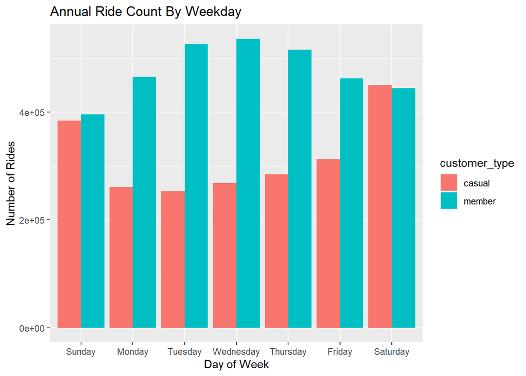

```r
viz_trips_by_weekday <- ggplot(data = trips_by_weekday)+
  geom_col(mapping = aes(x = weekday,
                         y = ride_count,
                         fill = customer_type),
           position = 'dodge')+
  labs(title = "Annual Ride Count By Weekday",
       x = "Day of Week",
       y = "Number of Rides",
       )
print(viz_trips_by_weekday)
```

## **10.2a Preferred Weekdays**

#### This visualization reveals that casual riders have a clear preference for weekend rides. Casual ridership exceeds member ridership on Saturdays, and nearly meets member ride counts on Sundays.

#### During the work week, member ridership far exceeds casual ridership. Members ride most frequently on Tuesdays, Wednesdays, and Thursdays.

#### During the work week, casual riders ride most frequently on Fridays and Thursdays.

```r
rm(trips_by_weekday)
```

## **10.2b Ride Start Time Analysis: Workdays**

#### Our initial visualization indicates heavy member usage during the work week, and could mean members use the system for business commuting or other task-based uses beyond recreation. In order to investigate this further, I will break out weekend and weekday rides into seperate data frames and observe when rides begin.

```r
#### Filtering workdays

trips_workday <- trips %>%
  filter(workday_weekend == 'workday')
```

#### Summarizing workday start hours

```r
trips_by_starting_hour_workday <- trips_workday %>%
  group_by(customer_type,start_hour) %>%
  summarize(avg_trip_length = mean(trip_length),
            ride_count = n_distinct(ride_id)
  )
```

#### Visualizing

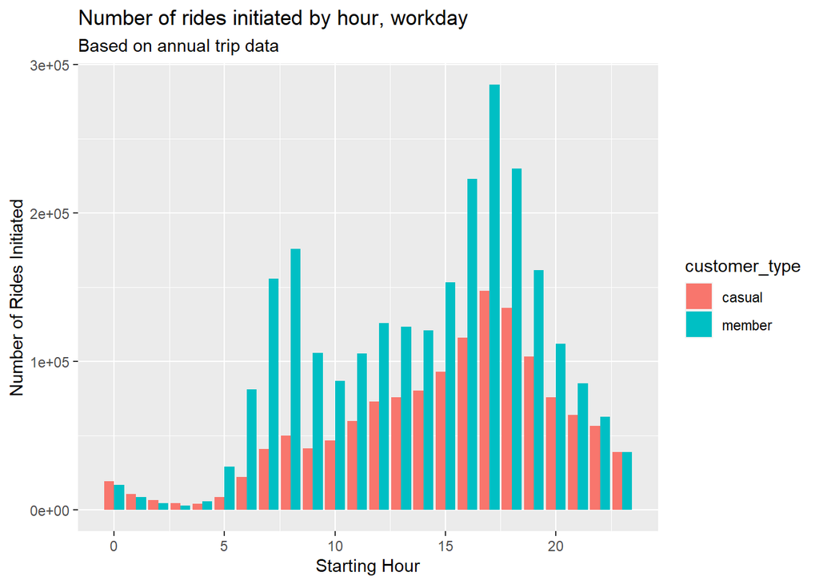

```r
viz_starting_hour_workday <- ggplot(data = trips_by_starting_hour_workday)+
  geom_col(mapping = aes(x = start_hour,
                         y = ride_count,
                         fill = customer_type),
           position = 'dodge'
                      )+
  labs(title = "Number of rides initiated by hour, workday",
       subtitle = "Based on annual trip data",
       x = "Starting Hour",
       y = "Number of Rides Initiated")
print(viz_starting_hour_workday)
```

```r
rm(trips_by_starting_hour_workday)
```

## **10.2b Ride Start Time Analysis: Workdays**

#### Casual: Casual riders demonstrate significantly different behavior on weekdays. Casual riders largely forgo the AM rush hour period of 7am through 10:59am, with only 13.03% of casual rides starting during this period. Casual ridership increases from 11am to 3:59pm, when 27.76% of casual rides initiate, and then peaks during the 4pm to 7:59pm period, which makes up 36.50% of their daily rides.

#### These findings could indicate that while some members use the system for morning commutes, there is an increased demand during the PM rush hour, either due to a lower need to arrive to destinations on time, or a desire to travel within a business district after work hours to entertainment and other social activities. We will study this more closely when analyzing trip duration (comparing am to pm trip durations) and station-to-station data.

## **10.2c Ride Start Time Analysis: Weekends**

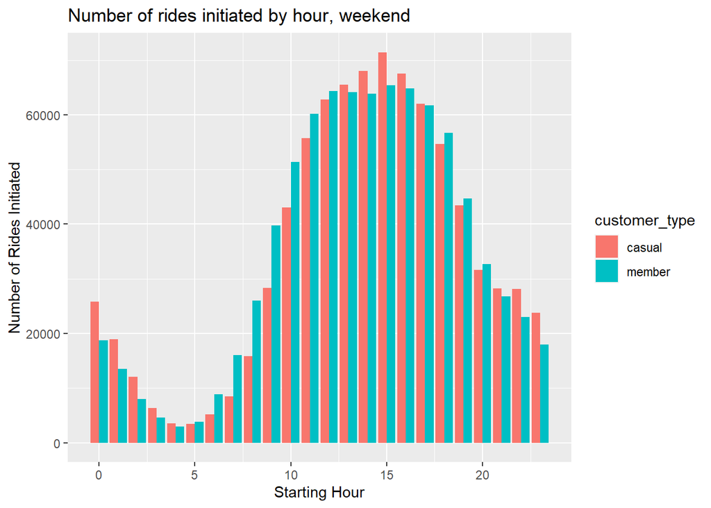

```r
trips_weekend <- trips %>%
  filter(workday_weekend == 'weekend')

trips_by_starting_hour_weekend <- trips_weekend %>%
  group_by(customer_type,start_hour) %>%
  summarize(avg_trip_length = mean(trip_length),
            ride_count = n_distinct(ride_id)
  )

viz_starting_hour_weekend <- ggplot(data = trips_by_starting_hour_weekend)+
  geom_col(mapping = aes(x = start_hour,
                         y = ride_count,
                         fill = customer_type),
           position = 'dodge'
  )+
  labs(title = "Number of rides initiated by hour, weekend",
       x = "Starting Hour",
       y = "Number of Rides Initiated")
print(viz_starting_hour_weekend)
```

```r
rm(trips_by_starting_hour_weekend, trips_weekend)
```

## **10.2c Ride Start Time Analysis: Weekends**

#### Weekend ride data shows an important shift in rider behavior: casual ridership trends much more closely to member ridership in terms of rides initiated by hour, and in some cases exceeds hourly member ridership.

#### Casual rides make up the majority of system-wide rides from 9pm through 4:59am, as well as from 1pm through 5:59pm.

#### We will need to study supporting data like trip duration and station-to-station behavior, but it does appear that casual riders are using Cyclistic in a largely recreational capacity, or as a way to attend or return from social activities.

#### When reviewing this data, I looked into Chicago’s mass transit system, the L, and found that six of the system’s eight lines close from between 1am and 2am and reopen between 4am and 5am. It is possible that the heavy late-night casual ridership numbers are in part a result of this lack of transportation alternatives.

#### The higher number of member riders using the system from 5am through 12:59pm on weekends could indicate commuting activity for those working weekends, but also points to another factor: weather.

#### Morning temperatures are generally cooler than during the midday and evening. This willingness to ride during less comfortable periods of the day could indicate that members are either more tolerant of the cold, or are active enough cyclists that they own better apparel to offset this discomfort. Both possiblities suggest that members are more experienced cyclists.

## **10.3a Identifying Peak Season**

#### While our start time analysis is helpful, Chicago’s weather likely has a major impact in overall system usage for member and casual riders. In order to study the impact of seasonality on system usage, I will break down ride counts by month, and then drill down to a specific week or band of weeks. Ideally, this will reveal peak casual ridership, which the marketing team can use as a trigger for when to initiate their marketing campaign.

```r
trips_by_month <- trips %>%
  group_by(month, customer_type) %>%
  summarize(avg_trip_length = mean(trip_length),
            ride_count = n_distinct(ride_id)
  )
```

#### In order to better visualize the member/casual split, I will now use the mutate command to create a percent breakdown of member versus casual rides.

```r
trips_by_month_pct <- trips_by_month %>%
  mutate(percent_of_rides = ((ride_count/sum(ride_count))*100)
  )
```

#### Now to visualize and determine peak months of system usage.

[figure not shown]

```r
viz_trips_by_month <- ggplot(data = trips_by_month_pct)+
  geom_col(mapping = aes(x = month,
                         y = ride_count,
                         fill = customer_type),
           position = 'dodge'
  )+
  labs(title = "Number of rides per week, segmented by customer type",
       x = "Month",
       y = "Ride Count",
       subtitle = "Avg Member Ride Count: 278,844 (Blue Line),
       Avg Casual Ride Count: 184,477(Red Line)")+
  geom_hline(yintercept=278844, linetype="dashed", color = "blue")+
  geom_hline(yintercept=184477, linetype="dashed", color = "red")
print(viz_trips_by_month)
```

## **10.3a Identifying Peak Season**

#### An initial review of this visualization indicates that member activity peaks in August, while casual activity peaks in July. Additionally, member and casual monthly ride counts exceed their monthly averages from May through October.

#### While both groups of customers see decreased ridership from November through April, casual riders show a far more significant drop off in Cyclistic usage when compared to member riders.

#### Monthly member ridership drops an average of 38.48% from November through April, while casual monthly ridership drops by an average of 68.79% during the same period.

#### Based on these observations, it seems likely that members are generally more tolerant of poor or cold weather, while casual riders are more fair-weather riders.

## **10.3b Identifying Peak Season**

#### While the raw ride count by month indicates July is the height of casual customer activity, I also wish to identify the month where casual riders make up the highest percentage of overall rides compared to members using the “percent_of_rides” statistic I calculated in 10.3a.

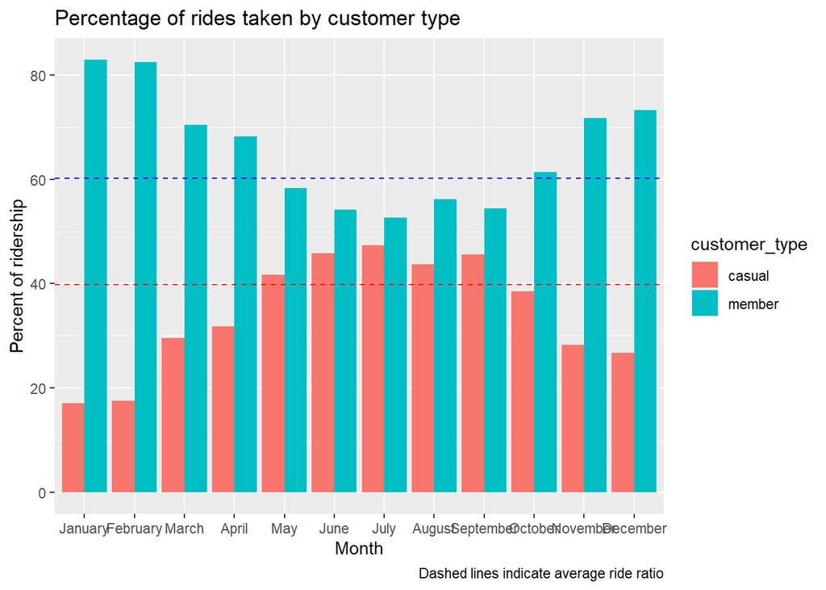

```r
viz_trips_by_month_pct <- ggplot(data = trips_by_month_pct)+
  geom_col(mapping = aes(x = month,
                         y = percent_of_rides,
                         fill = customer_type),
           position = 'dodge'
  )+
  labs(title = "Percentage of rides taken by customer type",
       caption = "Dashed lines indicate average ride ratio",
       x = "Month",
       y = "Percent of ridership")+
  geom_hline(yintercept= 60.18, linetype="dashed", color = "blue") +
  geom_hline(yintercept= 39.82, linetype="dashed", color = "red")
print(viz_trips_by_month_pct)
```

```r
rm(trips_by_month, trips_by_month_pct)
```

## **10.3b Comparing Casual/Member Split By Month**

#### The above visualization confirms that July is our prime time for targetting casual riders. Based on our data, casual riders make up 47.31% of all rides in July. Over the course of a full year, casual riders only make up 39.82% of all trips.

## **10.3c Isolating Peak Weeks**

#### Now that we know July is the peak month for casual riders, we will drill down to the calendar week level to ensure we activate the campaign when casual riders make up the largest percentage of overall rides. The following dataframe includes the calendar weeks of July (calendar weeks 26 - 30), as well as the last three weeks of June and first two weeks of August to ensure accurate findings.

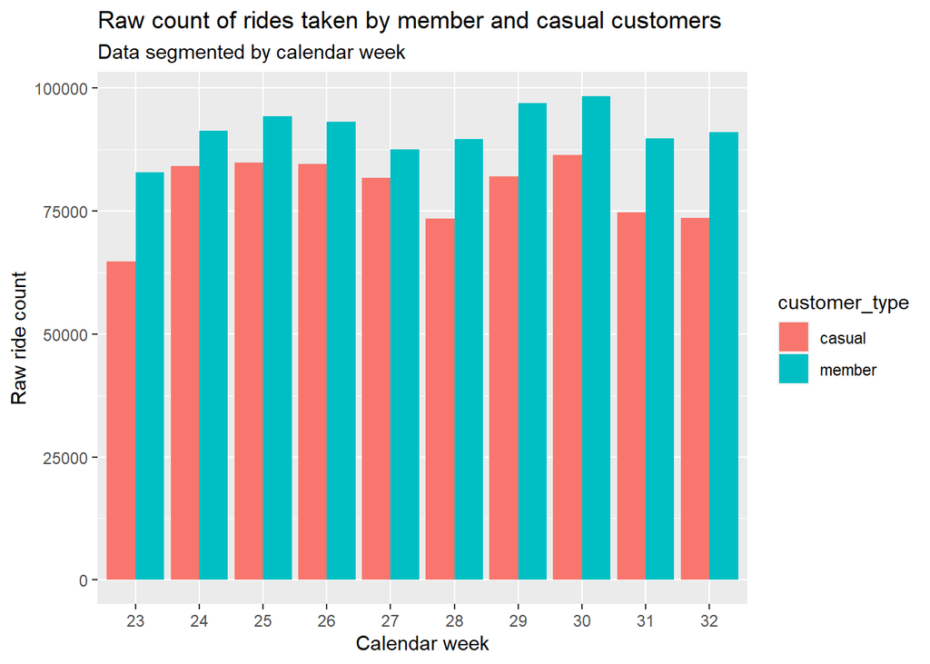

```r
trips_by_peak_week <- trips %>%
  filter(week >= 23 & week <= 32) %>%
  group_by(week, customer_type) %>%
  summarize(avg_trip_length = mean(trip_length),
            ride_count = n_distinct(ride_id)
  ) %>%
    mutate(percent_of_rides = ((ride_count/sum(ride_count))*100)
    )

#### Visualizing raw weekly count of casual/member rides

viz_trips_by_peak_week_raw_count <- ggplot(trips_by_peak_week)+
  geom_col(mapping = aes(x = week,
                         y = ride_count,
                         fill = customer_type),
           position = 'dodge')+
  labs(title = "Raw count of rides taken by member and casual customers",
       subtitle = "Data segmented by calendar week",
       x = "Calendar week",
       y = "Raw ride count")
print(viz_trips_by_peak_week_raw_count)
```

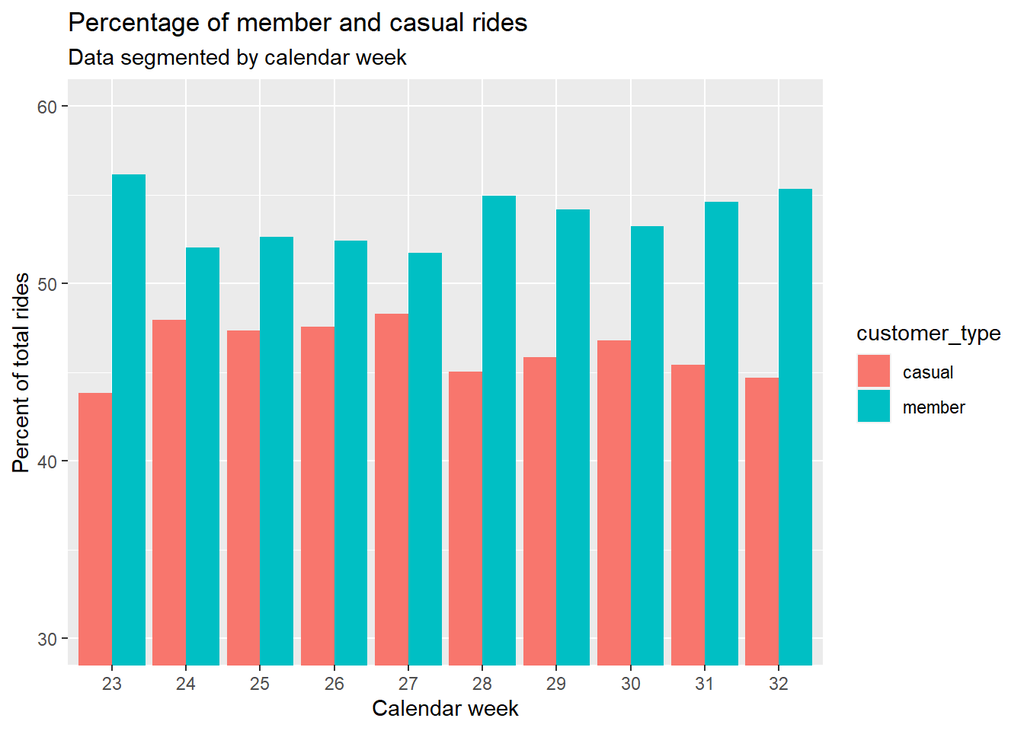

```r
#### Visualizing the ratio of casual to member rides

viz_trips_by_peak_week <- ggplot(trips_by_peak_week)+
  geom_col(mapping = aes(x = week,
                         y = percent_of_rides,
                         fill = customer_type),
           position = 'dodge')+
  labs(title = "Percentage of member and casual rides",
       subtitle = "Data segmented by calendar week",
       x = "Calendar week",
       y = "Percent of total rides")+
  coord_cartesian(ylim=c(30,60))
print(viz_trips_by_peak_week)
```

## **10.3c July in Detail**

#### The above visualizations present a clearer picture at the calendar-week-level. Although casual ride counts peak in July (week 30), ride counts are nearly as high, but more consistently so, during calendar weeks 24 through 27 (late June and early July). This is backed by the second visualization, which shows higher percentages of casual rides during weeks 24 through 27.

#### Based on these observations, we now know that **casual riders make up the largest percentage of the total rider population during weeks 24 through 27**, and the digital marketing team should target casual riders during this period. Further, this will be the primary period of time we will study when reviewing member/casual behavior later in the analysis.

## **10.4 How Weather Dictates Peak Season**

#### Rather than recommending the digital marketing team initiate their campaign during weeks 24 and 27, I want to understand what factors made these weeks so popular among casual riders. Based on our analysis to this point, I have a hypothesis that casual riders are more sensitive to weather conditions, so the following analysis will test that theory.

```r
chicago_weather_by_week_filtered <- chicago_weather %>%  ## filtering weather data to relevant time period and condensing records into weekly averages
  group_by(week) %>%
  summarize(mean_temp = mean(temp),
            mean_humidity = mean(humidity),
            sum_precip = sum(precip),           ## Using sum of rainfall in lieu of average to avoid one day skewing results for the week
            mean_wind_speed = mean(windspeed)) %>%
             filter(week >= 23 & week <= 32)
```

## **10.4a Temperature by week**

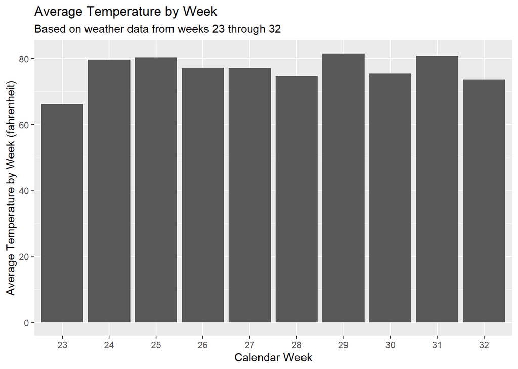

```r
viz_weather_week_temp <- ggplot(data = chicago_weather_by_week_filtered)+
  geom_col(mapping = aes(x = week,
                         y = mean_temp))+
  labs(title = "Average Temperature by Week",
       subtitle = "Based on weather data from weeks 23 through 32",
       x = "Calendar Week",
       y = "Average Temperature by Week (fahrenheit)")
print(viz_weather_week_temp)
```

## **10.4a Temperature and Peak Season**

#### From week 23 to 24, we see an increase in weekly average temperatures of 13.60 degrees from 66.09 to 79.69 degrees, coinciding with the uptick in casual ridership in week 24. Temperatures then remain around 80 degrees for the remainder of our period of study.

#### This bump in temperature could be the inciting incident for peak ridership, but further evaluation is required. I will now run a pearson correlation test to determine the strength of this correlation.

```r
trips_by_peak_week_casual <- trips_by_peak_week %>%
filter(customer_type == 'casual')

trips_by_peak_week_casual_1 <- bind_rows(trips_by_peak_week_casual,
                                         right_join(chicago_weather_by_week_filtered,
                                                    trips_by_peak_week_casual,by="week"))

trips_by_peak_week_casual_2 <- na.omit(trips_by_peak_week_casual_1)

weather_correlation_temp <- cor(trips_by_peak_week_casual_2$ride_count,
                                trips_by_peak_week_casual_2$mean_temp,
                                method = 'pearson')
print(weather_correlation_temp)
```

```
## [1] 0.7097007
```

#### Based on this test, it appears that temperature has a **strong** correlation to casual ridership of 0.71.

## **10.4b Wind Speed by Week**

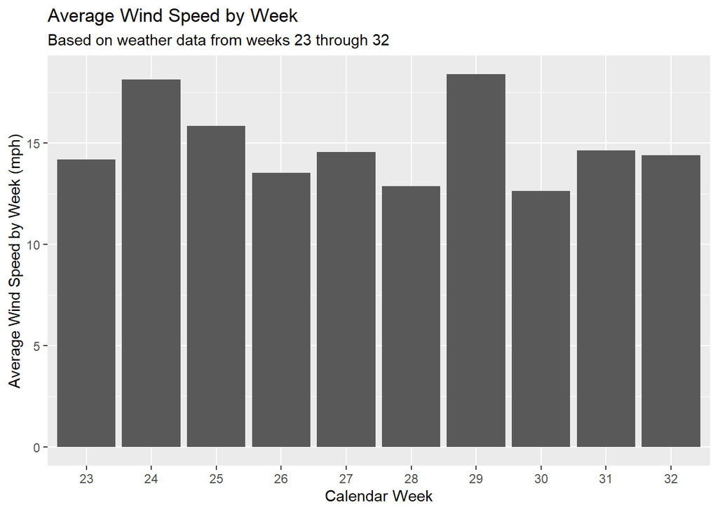

```r
viz_weather_week_wind_speed <- ggplot(data = chicago_weather_by_week_filtered)+
  geom_col(mapping = aes(x = week,
                         y = mean_wind_speed))+
  labs(title = "Average Wind Speed by Week",
       subtitle = "Based on weather data from weeks 23 through 32",
       x = "Calendar Week",
       y = "Average Wind Speed by Week (mph)")
print(viz_weather_week_wind_speed)
```

#### **10.4b Wind Speed and Peak Season**

```r
weather_correlation_wind_speed <- cor(trips_by_peak_week_casual_2$ride_count,
                                      trips_by_peak_week_casual_2$mean_wind_speed,
                                      method = 'pearson')
print(weather_correlation_wind_speed)
```

```
## [1] 0.2602383
```

#### Based on this test, wind speed has a **low** correlation to casual ridership of 0.26.

## **10.4c Average Percent Humidity by Week**

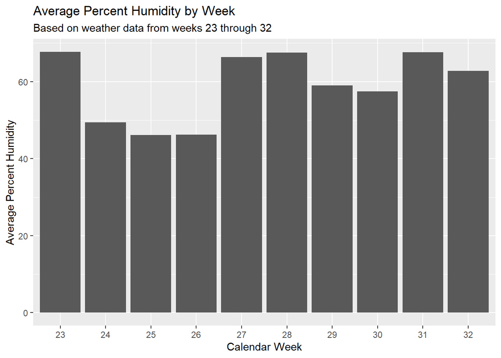

```r
viz_weather_week_humidity <- ggplot(data = chicago_weather_by_week_filtered)+
  geom_col(mapping = aes(x = week,
                         y = mean_humidity))+
  labs(title = "Average Percent Humidity by Week",
       subtitle = "Based on weather data from weeks 23 through 32",
       x = "Calendar Week",
       y = "Average Percent Humidity")
print(viz_weather_week_humidity)
```

## **10.4c Average Percent Humidity and Peak Season**

#### This presents a key finding: humidity drops by 18.23% from week 23 to 24, and increases by 20.10% from week 26 to 27 and remains high. It is likely that this increase in discomfort disuaded casual riders from being as active with Cyclistic over the course of a sweaty week 27.

#### These findings are backed by the average humidity of week 30 (57.43%). This is the lowest average humidity from weeks 27 through 32 and coincides with peak casual ridership.

```r
weather_correlation_humidity <- cor(trips_by_peak_week_casual_2$ride_count,
                                    trips_by_peak_week_casual_2$mean_humidity,
                                    method = 'pearson')
print(weather_correlation_humidity)
```

```
## [1] -0.7361105
```

#### Based on this test, humidity has a **strong** inverse correlation to casual ridership of -0.74

## **10.4d Total Rainfall by Week**

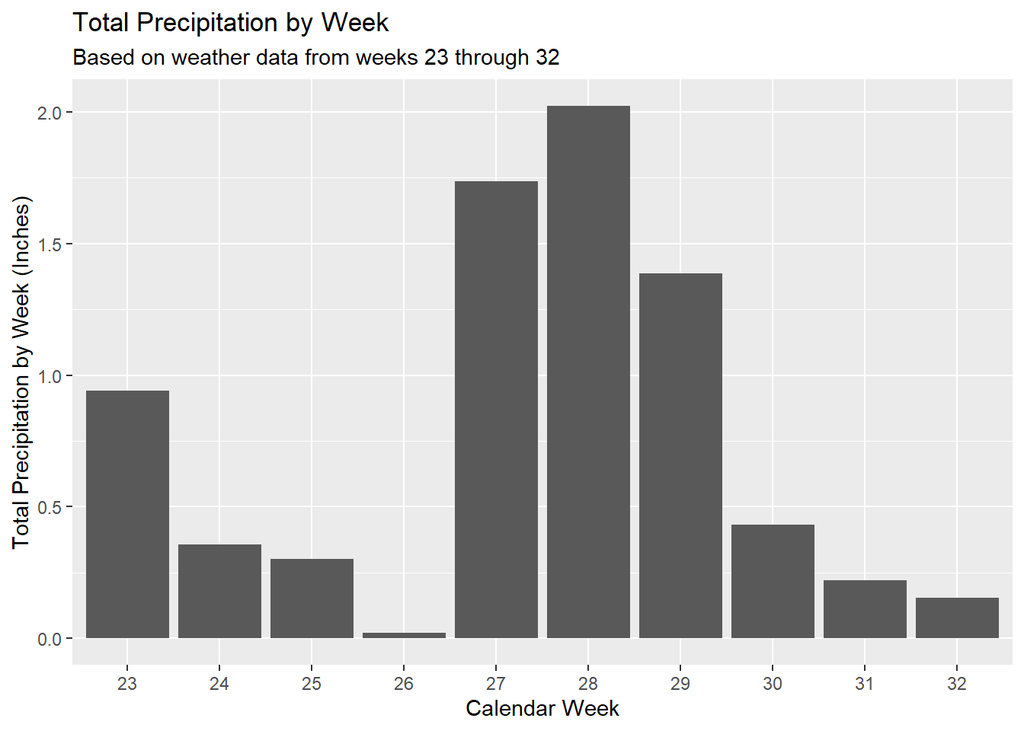

```r
viz_weather_week_precip_total <- ggplot(data = chicago_weather_by_week_filtered)+
  geom_col(mapping = aes(x = week,
                         y = sum_precip))+
  labs(title = "Total Precipitation by Week",
       subtitle = "Based on weather data from weeks 23 through 32",
       x = "Calendar Week",
       y = "Total Precipitation by Week (Inches)")
print(viz_weather_week_precip_total)
```

## **10.4d Total Rainfall and Peak Season**

#### Total rainfall presents somewhat confounding findings. Rainfall fell below 0.5 inches during weeks 24 through 26, but spiked in weeks 27 through 29 before falling below 0.5 inches for the remainder of our period of study.

```r
weather_correlation_precip <- cor(trips_by_peak_week_casual_2$ride_count,
                                  trips_by_peak_week_casual_2$sum_precip,
                                  method = 'pearson')
print(weather_correlation_precip)
```

```
## [1] -0.2325573
```

#### Based on this test, actual rainfall has a **low** inverse correlation to casual ridership of -0.23. That said, the decrease in rainfall from week 23 to 24 may have been part of the factors that triggered the beginning of peak season. Rather than using this as a hard rule for peak season, I would consider rainfall below 0.5 inches to be a secondary or tertiary consideration when deciding to initiate the marketing team’s campaign.

```r
rm(trips_by_peak_week,
   weather_correlation_precip,
   weather_correlation_wind_speed,
   weather_correlation_temp,
   weather_correlation_humidity,
   trips_by_peak_week_casual,
   trips_by_peak_week_casual_1,
   trips_by_peak_week_casual_2,
   chicago_weather_by_week_filtered)
```

## **10.4e Implications of Weather Study**

#### Our study of weather patterns and casual ridership indicates that there are several triggers for casual riders to hit their peak season:

#### 1) Casual ridership increases when temperatures reach about 80 degrees, especially if there has been a double-digit increase in temperature from the prior week.

#### 2) Casual ridership increases when humidity is low, espescially when humidity levels sit below the annual average of 62.5%.

#### 3) Rainfall changes so much from week to week that it is difficult to draw a direct line from increased rain to lower casual ridership, however weeks with rainfall below 0.5 inches do see a slight increase in casual activity.

## **10.5 Evaluating Casual and Member Behavior**

#### Now that we know when to target casual members for the membership campaign, we will need to evaluate and compare member and casual rider behavior. These findings will help us flesh out some of our earlier observations and give the marketing team talking points they can use when developing their campaign.

#### When evaluating behavior, I will focus on trip duration, bike preference (electric and classic), how bike type impacts trip duration, and how day and time of day impacts these characteristics.

#### I will begin my analysis using the full year’s worth of data for a high-level understanding of customer behvior, then drill down to weeks 24 through 27 to ensure our marketing efforts are honed to the finest possible point.

## **10.5a Bike Type, Trip Duration, and Customer Split**

#### To begin, we will first establish baseline stats for member and casual behavior over the course of a year.

#### The dataframe below includes:

#### 1) Average trip duration for each customer/bike type combination,

#### 2) Raw count of rides taken by each customer/bike type combination,

#### 3) Percentage of rides on classic/electric bikes within each customer type

#### 4) Number of rides by each customer/bike type as a percentage of total annual rides

```r
basic_stats <- trips %>%
  group_by(customer_type, bike_type) %>%
  summarize(mean_trip_duration = mean(trip_length),
            ride_count = n_distinct(ride_id)) %>%
  mutate(classic_electric_split = ((ride_count/sum(ride_count))*100),
         pct_of_total_rides = ((ride_count/5559857)*100)
  )
view(basic_stats)
```

## **10.5b Bike Type Preference**

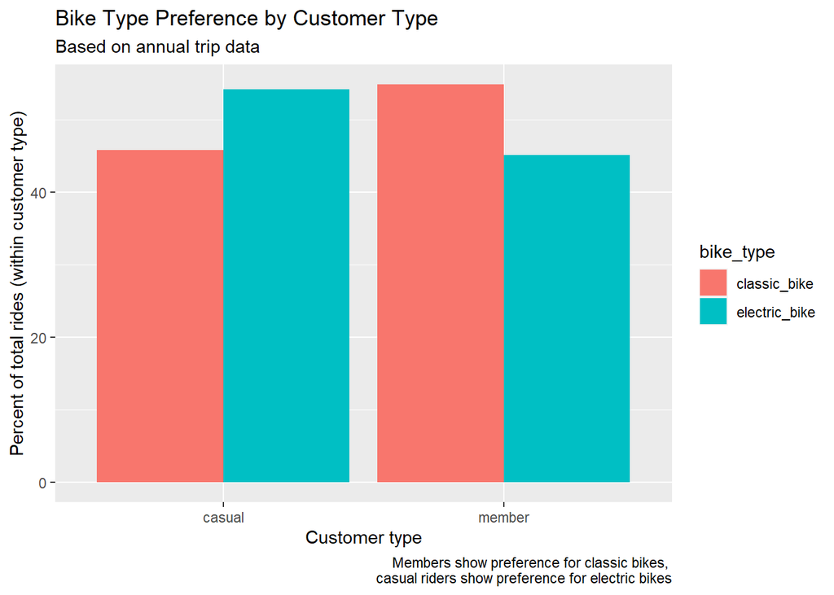

```r
viz_bike_type_preference <- ggplot(data = basic_stats)+
  geom_col(mapping = aes(x = customer_type,
                         y = classic_electric_split,
                         fill = bike_type),
           position = 'dodge')+
  labs(title = "Bike Type Preference by Customer Type",
       subtitle = "Based on annual trip data",
       caption = "Members show preference for classic bikes,
       casual riders show preference for electric bikes",
       x = "Customer type",
       y = "Percent of total rides (within customer type)"
       )
print(viz_bike_type_preference)
```